# Data Science Introductory Tutorial

## What Sells A Video Game?

One of the most surprisingly impressive markets that have been consistently growing over the past 30 years is the video game industry. If current trends continue, the global video game market is predicted to hit over 90 billion U.S. dollars in revenues (according to www.statista.com/statistics/246888/value-of-the-global-video-game-market/). Our task in this data walkthrough is to identify some predictive qualities of whether a video game will sell or not.

## What YOU Need:

While there are many different tools to work with large data sets effectively, in this tutorial you will need the following:

1) Python 2) [Jupyter Notebook](http://jupyter.readthedocs.io/en/latest/install.html)

Jupyter Notebook is a user friendly environment built primarily for data scientists. If you are new to Jupyter I would recommend reading over the quickstart manual while waiting for downloads and installs to finish [jupyter manual](https://jupyter-notebook-beginner-guide.readthedocs.io/en/latest/)

The following Libraries must also be downloaded:

1) Pandas 2) Numpy 3) Matplotlib 4) Seaborn

Lastly, and most importantly, the data set! (Found on kaggle.com) (https://www.kaggle.com/rush4ratio/video-game-sales-with-ratings)

I will discuss the libraries and their functionailty as we come across them.

Now we are ready to get cracking. The first thing to do is import the necessary libraries.

```python
import pandas as pd
import numpy as np
import matplotlib.pyplot as plt
import seaborn as sns
```

## Extracting the Data:

We have our libraries installed and imported and our data on hand. Now what? This is where our first two libraries, pandas and numpy come in. Python on its own is decent for setting up the data, but when it comes to analysis comes short. Pandas is the solution. Pandas uses two objects called series and dataframes, which are both contructed using numpy. Numpy is an extension that uses a multi-dimensional data structure and has extremely fast computational power. With these two libraries in cooperation, we are provided an effecive tool for data analysis. We begin by creating a pandas dataframe and storing the data (formatted in a CSV (comma seperated values file)) into this dataframe.

For a more detailed look on pandas and numpy visit [pandas quickstart](http://www.gregreda.com/2013/10/26/intro-to-pandas-data-structures/) and [numpy quickstart](https://www.python-course.eu/numpy.php)

```python
# Loading the data
videogame_data = pd.read_csv("Video_Games_Sales_as_at_22_Dec_2016.csv")

# Displaying the newly created dataframe
videogame_data.head()
```

|  | Name | Platform | Year_of_Release | Genre | Publisher | NA_Sales | EU_Sales | JP_Sales | Other_Sales | Global_Sales | Critic_Score | Critic_Count | User_Score | User_Count | Developer | Rating |
| --- | --- | --- | --- | --- | --- | --- | --- | --- | --- | --- | --- | --- | --- | --- | --- | --- |
| 0 | Wii Sports | Wii | 2006.0 | Sports | Nintendo | 41.36 | 28.96 | 3.77 | 8.45 | 82.53 | 76.0 | 51.0 | 8 | 322.0 | Nintendo | E |
| 1 | Super Mario Bros. | NES | 1985.0 | Platform | Nintendo | 29.08 | 3.58 | 6.81 | 0.77 | 40.24 | NaN | NaN | NaN | NaN | NaN | NaN |
| 2 | Mario Kart Wii | Wii | 2008.0 | Racing | Nintendo | 15.68 | 12.76 | 3.79 | 3.29 | 35.52 | 82.0 | 73.0 | 8.3 | 709.0 | Nintendo | E |
| 3 | Wii Sports Resort | Wii | 2009.0 | Sports | Nintendo | 15.61 | 10.93 | 3.28 | 2.95 | 32.77 | 80.0 | 73.0 | 8 | 192.0 | Nintendo | E |
| 4 | Pokemon Red/Pokemon Blue | GB | 1996.0 | Role-Playing | Nintendo | 11.27 | 8.89 | 10.22 | 1.00 | 31.37 | NaN | NaN | NaN | NaN | NaN | NaN |

Here we have a look at what our data looks like stored in the dataframe. All the information from the raw CSV file should be stored into this dataframe. The first step towards your life as a data scientist is done! Don't get too excited, because extracting the data is always the easiest step. Onto the next!

## Tidying Data

In this stage, we take our newly formed dataframe and clean it up a little. We are lucky that the creator of the csv file left us with a resonably tidy data table to begin, but there are a lot of sloppily organized data sets out there. The key things to be weary of when tidying data are:

- Making sure variable name and not values are stored in column headers
- Repetition of data is minimized
- Column headers are clearly and appropriately named
- Unnecessary data is removed
- Unavailable data is dealt with

While these are just a couple of the core principles to cleaning data, there are many ways in which you can organize your data to allow not only the reader a clear view of the table but also yourself! All in all the tidying data helps speed along the path to quicker and more thorough analysis.

For our dataframe, I chose to first remove the redundant columns from the dataframe. In this case, I removed the columns that contained the regional sales. One always has to be careful when removing data not to affect the results in any way. Here, I thought it was appropriate to remove these columns since we can simply consider the global sales as an aggragate.

```python
# Removing Redundant Columns
videogame_data = videogame_data.drop(['NA_Sales','EU_Sales','JP_Sales','Other_Sales'], axis=1)

videogame_data.head()
```

|  | Name | Platform | Year_of_Release | Genre | Publisher | Global_Sales | Critic_Score | Critic_Count | User_Score | User_Count | Developer | Rating |
| --- | --- | --- | --- | --- | --- | --- | --- | --- | --- | --- | --- | --- |
| 0 | Wii Sports | Wii | 2006.0 | Sports | Nintendo | 82.53 | 76.0 | 51.0 | 8 | 322.0 | Nintendo | E |
| 1 | Super Mario Bros. | NES | 1985.0 | Platform | Nintendo | 40.24 | NaN | NaN | NaN | NaN | NaN | NaN |
| 2 | Mario Kart Wii | Wii | 2008.0 | Racing | Nintendo | 35.52 | 82.0 | 73.0 | 8.3 | 709.0 | Nintendo | E |
| 3 | Wii Sports Resort | Wii | 2009.0 | Sports | Nintendo | 32.77 | 80.0 | 73.0 | 8 | 192.0 | Nintendo | E |
| 4 | Pokemon Red/Pokemon Blue | GB | 1996.0 | Role-Playing | Nintendo | 31.37 | NaN | NaN | NaN | NaN | NaN | NaN |

Next up is to simply rename and rearrange the columns. I rearrange the columns based on two factors. Firstly, the relatable variables should be neighboring. This helps reduce confusion when analyzing. Secondly, the more "pressing"/"important" variable towards the beginning of the table and less "pressing"/"important" variables towards the back. This is more a matter of preference, but personally, I find that organizing based on what variables I think matter helps with analyzation down the road.

For our data frame, there are certainly variable names that could be clearer as well as a drastic need to reorganize columns. We shall tidy below:

```python
# Renaming the columns
videogame_data.columns = ['Videogame','Platform','Release Year','Genre','Publisher','Global Sales','Critic Score','Critic Count','User Score','User Count','Developer','Rating']

# Organizing Columns
videogame_data = videogame_data[['Videogame','Global Sales','Developer','Publisher','Platform','Genre','Rating','Release Year','Critic Score','Critic Count','User Score','User Count']]

videogame_data.head()
```

|  | Videogame | Global Sales | Developer | Publisher | Platform | Genre | Rating | Release Year | Critic Score | Critic Count | User Score | User Count |
| --- | --- | --- | --- | --- | --- | --- | --- | --- | --- | --- | --- | --- |
| 0 | Wii Sports | 82.53 | Nintendo | Nintendo | Wii | Sports | E | 2006.0 | 76.0 | 51.0 | 8 | 322.0 |
| 1 | Super Mario Bros. | 40.24 | NaN | Nintendo | NES | Platform | NaN | 1985.0 | NaN | NaN | NaN | NaN |
| 2 | Mario Kart Wii | 35.52 | Nintendo | Nintendo | Wii | Racing | E | 2008.0 | 82.0 | 73.0 | 8.3 | 709.0 |
| 3 | Wii Sports Resort | 32.77 | Nintendo | Nintendo | Wii | Sports | E | 2009.0 | 80.0 | 73.0 | 8 | 192.0 |
| 4 | Pokemon Red/Pokemon Blue | 31.37 | NaN | Nintendo | GB | Role-Playing | NaN | 1996.0 | NaN | NaN | NaN | NaN |

There our data is looking much better! A tidy data frame goes a long way towards a cleaner analysis. There is only one glaring mess left to tidy. What do we do with all the unavailable values (marked by NaN by pandas)?

## Missing Data

When dealing with missing data, we always have to ask why the data is missing in order to properly deal with the missing values. Rarely is it that data is missing in a completely random fashion. On Kaggle, where we retrieved our data set, the explanation given is that Metacritic, where the data was scraped from, only covers a subset of the platforms. Another explanation given to us is that a portion of the games did not have information for all the variables. Metacritic more consistently reviews more popular games, but ultamately leaves the decision of game inclusion is based on whether the game was reviewed by multiple publications. Now that we know metacritic is an aggragation of reviews from other publications, we are more confident that explicit bias in our data is minimal. For sake of simplicity for this tutorial we are going to simply remove the rows that contain NaN. However there are [more ways](https://measuringu.com/handle-missing-data/) to deal with missing data involving various machine learning techniques.

#### Important Note*

dropping values is not always as clean. Without asking why the data points are missing, one can possible remove a subcategory of data that is pertinent to the analysis! You might be inserting an unforeseen bias into your analysis as well. Always ask why the data is missing!

```python
# Removing the missing values marked by NaN
videogame_data = videogame_data.dropna()
videogame_data.head()
```

|  | Videogame | Global Sales | Developer | Publisher | Platform | Genre | Rating | Release Year | Critic Score | Critic Count | User Score | User Count |
| --- | --- | --- | --- | --- | --- | --- | --- | --- | --- | --- | --- | --- |
| 0 | Wii Sports | 82.53 | Nintendo | Nintendo | Wii | Sports | E | 2006.0 | 76.0 | 51.0 | 8 | 322.0 |
| 2 | Mario Kart Wii | 35.52 | Nintendo | Nintendo | Wii | Racing | E | 2008.0 | 82.0 | 73.0 | 8.3 | 709.0 |
| 3 | Wii Sports Resort | 32.77 | Nintendo | Nintendo | Wii | Sports | E | 2009.0 | 80.0 | 73.0 | 8 | 192.0 |
| 6 | New Super Mario Bros. | 29.80 | Nintendo | Nintendo | DS | Platform | E | 2006.0 | 89.0 | 65.0 | 8.5 | 431.0 |
| 7 | Wii Play | 28.92 | Nintendo | Nintendo | Wii | Misc | E | 2006.0 | 58.0 | 41.0 | 6.6 | 129.0 |

```python
# Checking how many values we are left
videogame_data.shape
```

```
(6825, 12)
```

## Analysis

The easiest way to discern whether two numeric variables share a relationship is to fit a linear regression to the two variables. This is where the Seaborn tool comes in. While pandas, through numpy, does have some great plotting options, I personally found Seaborn to be an simpler alternative to fitting linear regression. Seaborn is built on top of the matplotlib library and offers a wider variety of plotting options geared towards those focusing on statistical analysis. Click here for the proper documentation on [Seaborn](https://seaborn.pydata.org/) and on [Matplotlib](https://matplotlib.org/).

First, we will see what the relationship between global sales and critic scores looks like. Using an educated guess, I would suspect that there is a positive relationship between higher critic scores and higher global sales because, intuitively, games with better ratings should have a larger appeal.

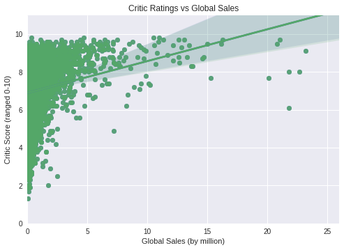

```python
# First, I am going to rescale the critic score to align with the scaling on the user score for ease of interpretation.
videogame_data[['Critic Score']] = videogame_data[['Critic Score']].astype('int')
videogame_data[['Critic Score']] = videogame_data[['Critic Score']].apply(lambda x: x/10)

# Now, plotting the data
ax = sns.regplot(x='Global Sales', y='Critic Score', data = videogame_data)
ax.set(xlabel = 'Global Sales (by million)', ylabel = 'Critic Score (ranged 0-10)')
ax.set_title('Critic Ratings vs Global Sales')
plt.ylim(0, 11)
plt.xlim(0,26)
plt.show()
```